# EDA on dataset

DonghyunPark

2023-04-16

```r
library(tidyverse)
library(showtext)
library(GGally)
library(lubridate)
library(corrplot)

font_add_google("Nanum Gothic", "nanum")
showtext_auto()
```

# Data loading

```r
data <- read.csv("/Users/donghyunpark/Documents/Seoul National University/3rd year 1st semester/Data mining/1차 프로젝트/1차 프로젝트 데이터/2021_서울_화재_(데이터_에너지_전기점검)_대분류_2.csv", fileEncoding = "euc-kr")
```

# Str for original data

```r
data %>% str
```

```
## 'data.frame':    3189 obs. of  33 variables:
##  $ 화재발생년월일              : chr  "2021-01-01 0:00" "2021-01-01 1:15" "2021-01-01 6:13" "2021-01-01 10:33" ...
##  $ 시도                        : chr  "서울특별시" "서울특별시" "서울특별시" "서울특별시" ...
##  $ 시군구                      : chr  "구로구" "강남구" "강남구" "중랑구" ...
##  $ 화재유형                    : chr  "건축,구조물" "기타(쓰레기 화재등)" "건축,구조물" "건축,구조물" ...
##  $ 발화열원대분류              : chr  "불꽃, 불티" "담뱃불, 라이터불" "작동기기" "작동기기" ...
##  $ 발화요인대분류              : chr  "부주의" "부주의" "전기적 요인" "전기적 요인" ...
##  $ 최초착화물대분류            : chr  "기타" "쓰레기류" "합성수지" "전기,전자" ...
##  $ 인명피해.명.소계            : int  0 0 0 0 0 0 0 0 0 0 ...
##  $ 사망                        : int  0 0 0 0 0 0 0 0 0 0 ...
##  $ 부상                        : int  0 0 0 0 0 0 0 0 0 0 ...
##  $ 재산피해소계                : int  50 22 1865 352 100 498 50 27 2292 13 ...
##  $ 장소대분류                  : chr  "산업시설" "기타" "주거" "운수자동차시설" ...
##  $ 기온                        : num  -7.9 -7.2 -8.9 -6.4 -1.2 -1.2 0.7 -1.4 -1.8 -6.4 ...
##  $ 풍향                        : num  335.7 321 50.7 0 174.6 ...
```

[output cut: 19 more lines]

# Data 전처리

## Eliminate variables

시도, 인명피해.명.소계, 사망, 부상 제외, 결측치 제외

```r
data <- data %>%
  dplyr::select(-"시도", -"인명피해.명.소계", -"사망", -"부상")%>%
  na.omit()
```

## 날짜에서 시간만 추출

```r
datetime <- ymd_hm(data$화재발생년월일)

data <- data %>%
  mutate(hour = hour(datetime), day = day(datetime), month = month(datetime), minute = minute(datetime)) %>%
  select(-화재발생년월일)
```

## 최종 Colnames

```r
colnames(data)
```

```
##  [1] "시군구"                       "화재유형"
##  [3] "발화열원대분류"               "발화요인대분류"
##  [5] "최초착화물대분류"             "재산피해소계"
##  [7] "장소대분류"                   "기온"
##  [9] "풍향"                         "풍속"
## [11] "강수량"                       "습도"
## [13] "차량수"                       "총생활인구수"
## [15] "내국인생활인구수"             "장기체류외국인인구수"
## [17] "단기체류외국인인구수"         "일최대인구수"
## [19] "일최소인구수"                 "주간인구수.09.18."
## [21] "야간인구수.19.08."            "일최대이동인구수"
## [23] "서울외유입인구수"             "동일자치구행정동간이동인구수"
## [25] "자치구간이동인구수"           "가스이용량"
## [27] "전기이용량"                   "전기점검_불합격_합계"
## [29] "hour"                         "day"
## [31] "month"                        "minute"
```

# Exploratory Data Analysis

# 재산피해 외의 변수 분석

## 인구수 사이의 연관성

### Construct data

```r
data_population <- data %>%
  select("총생활인구수", "내국인생활인구수", "장기체류외국인인구수", "단기체류외국인인구수", "일최대인구수", "일최소인구수", "주간인구수.09.18.", "야간인구수.19.08.", "일최대이동인구수", "서울외유입인구수", "동일자치구행정동간이동인구수", "자치구간이동인구수")
```

### Correlation between variables

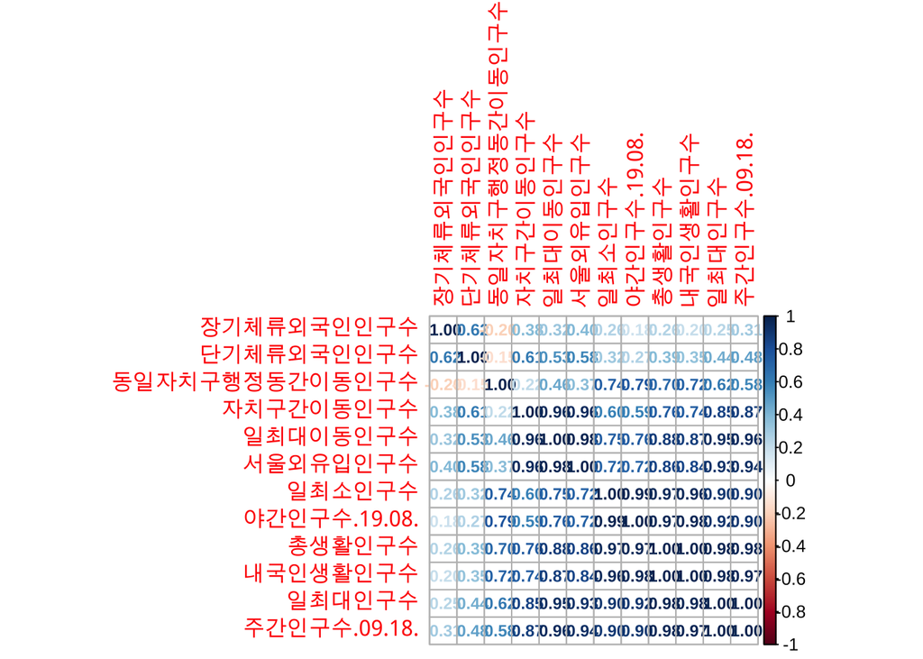

```r
corrplot(cor(data_population), method = 'number', number.cex = 0.75, order = 'hclust')
```

장기체류외국인인구수, 단기체류외국인인구수는 다른 인구 데이터와 비교했을 때 최대 0.5~0.6 정도의 상관관계를 띔. 동일자치구행정동간 이동인구수는 일최소인구수, 야간인구수, 총생활인구수, 내국인생활인구수와 0.7정도의 상관관계를 보임. 일 최소인구수, 야간인구수, 총 생활인구수, 내국인생활인구수, 일최대인구수, 주간인구수는 모두 0.9 이상의 강한 상관관계를 나타냄.

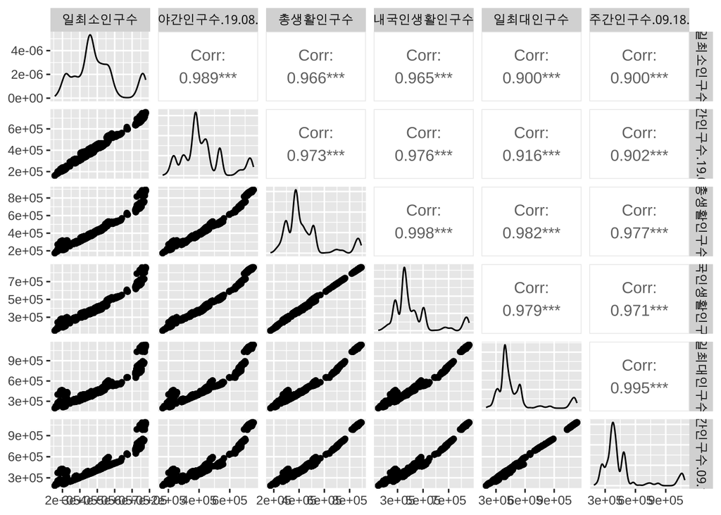

```r
data_population %>%
  select("일최소인구수", "야간인구수.19.08.", "총생활인구수", "내국인생활인구수", "일최대인구수", "주간인구수.09.18.")%>%
  ggpairs()
```

이들 중에서도 유사한 카테고리로 판단되는 총 생활인구수, 내국인 생활인구수는 거의 1에 가까운 상관관계를 보였고, 낮에 주로 사람이 많이 돌아다니므로 주간 인구수와 일 최대 인구수 역시 강한 상관관계가 나타남. 비슷한 이유로 야간 인구수와 일 최소 인구수가 강한 상관관계를 보임.

## Plot variables

### 총 생활인구수 vs 내국인 생활인구수

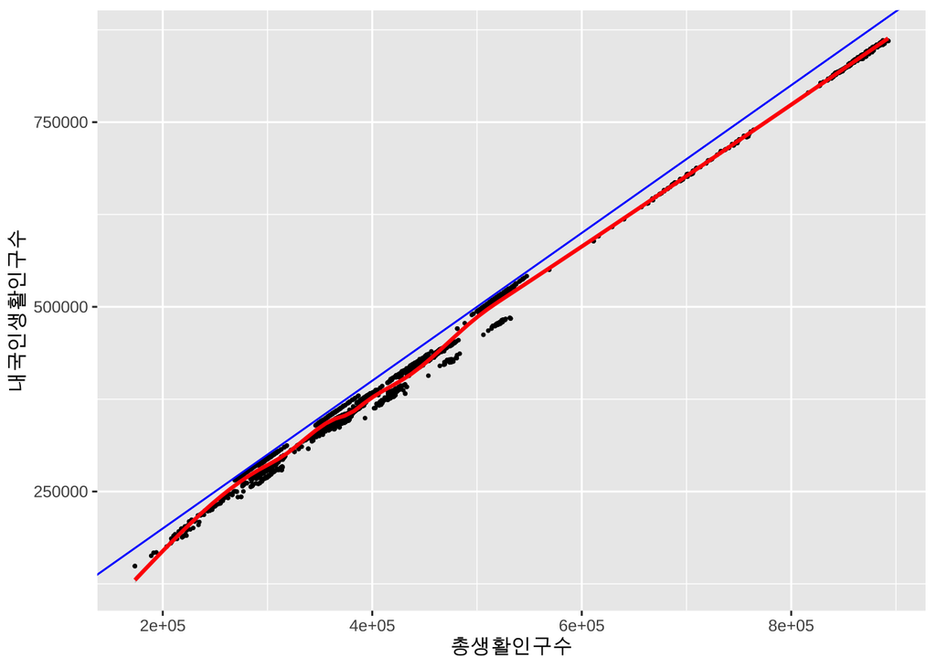

```r
data_population %>%
  select("총생활인구수", "내국인생활인구수") %>%
  ggplot(aes(x = `총생활인구수`, y = `내국인생활인구수`))+
  geom_point(size = 0.5)+
  geom_abline(color = "blue")+
  geom_smooth(color = "red")
```

### 총 생활인구수와 내국인 생활인구수는 선형 관계에 놓여있는가?

```r
lm_living_population.fit <- lm(내국인생활인구수 ~ 총생활인구수, data = data_population)
summary(lm_living_population.fit)
```

```
##
## Call:
## lm(formula = 내국인생활인구수 ~ 총생활인구수, data = data_population)
##
## Residuals:
##    Min     1Q Median     3Q    Max
## -31221  -4949   -679  10427  15705
##
## Coefficients:
##                Estimate Std. Error t value Pr(>|t|)
## (Intercept)  -1.129e+04  4.698e+02  -24.02   <2e-16 ***
## 총생활인구수  9.813e-01  1.005e-03  976.47   <2e-16 ***
## ---
## Signif. codes:  0 '***' 0.001 '**' 0.01 '*' 0.05 '.' 0.1 ' ' 1
##
## Residual standard error: 9135 on 3180 degrees of freedom
## Multiple R-squared:  0.9967, Adjusted R-squared:  0.9967
## F-statistic: 9.535e+05 on 1 and 3180 DF,  p-value: < 2.2e-16
```

Residual plot

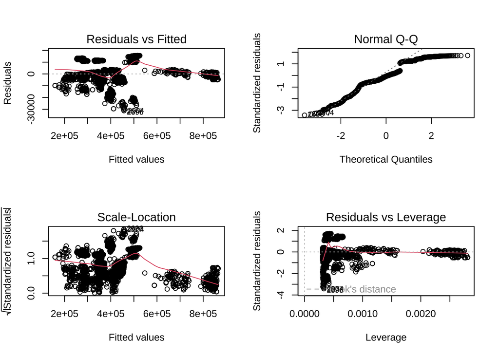

```r
par(mfrow = c(2,2))
plot(lm_living_population.fit)
```

Cluster가 되어있는 것으로 보아 각 구가 내국인 생활인구수와 총 생활인구수의 관계를 결정하는 듯 보인다.

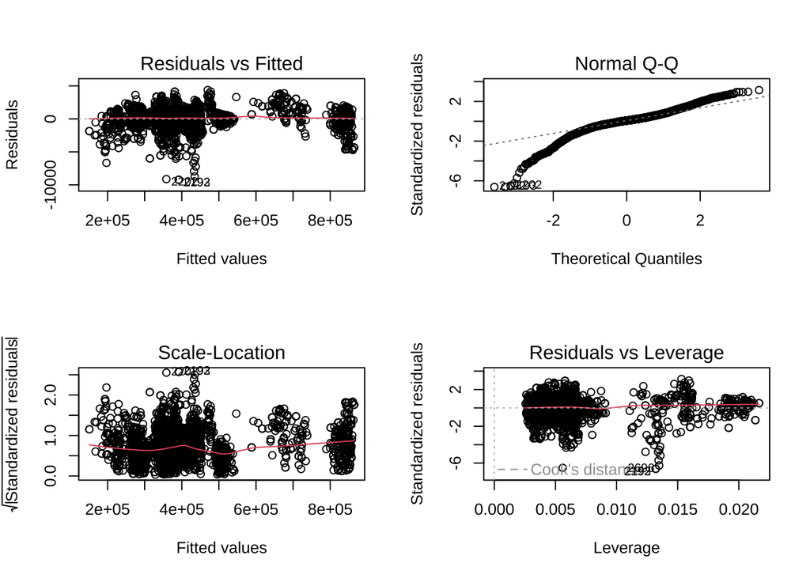

```r
lm_living_population.fit2 <- lm(내국인생활인구수 ~ 총생활인구수 + 총생활인구수:시군구, data = data)

par(mfrow = c(2,2))
plot(lm_living_population.fit2)
```

몇 이상치를 제외하고 잔차가 잘 fitted 된 그림이다. 즉, 구와 총 생활인구수의 interaction을 넣으면 내국인 생활인구수의 영향을 줄일 수 있음을 시사한다.

### 주간인구수 vs 일 최대인구수

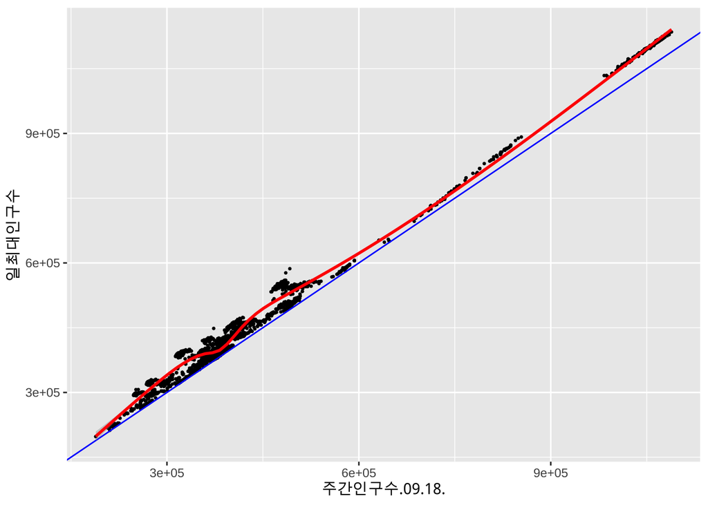

```r
data_population %>%
  select("주간인구수.09.18.", "일최대인구수") %>%
  ggplot(aes(x = `주간인구수.09.18.`, y = `일최대인구수`))+
  geom_point(size = 0.5)+
  geom_abline(color = "blue")+
  geom_smooth(color = "red")
```

### 주간 인구수와 일 최대 인구수는 선형 관계에 놓여있는가?

```r
lm_max_population.fit <- lm(일최대인구수 ~ 주간인구수.09.18., data = data_population)
summary(lm_max_population.fit)
```

```
##
## Call:
## lm(formula = 일최대인구수 ~ 주간인구수.09.18., data = data_population)
##
## Residuals:
##    Min     1Q Median     3Q    Max
## -32095 -18277  -3259  14464  62250
##
## Coefficients:
##                    Estimate Std. Error t value Pr(>|t|)
## (Intercept)       2.373e+04  9.017e+02   26.32   <2e-16 ***
## 주간인구수.09.18. 1.018e+00  1.797e-03  566.31   <2e-16 ***
## ---
## Signif. codes:  0 '***' 0.001 '**' 0.01 '*' 0.05 '.' 0.1 ' ' 1
##
## Residual standard error: 21030 on 3180 degrees of freedom
## Multiple R-squared:  0.9902, Adjusted R-squared:  0.9902
## F-statistic: 3.207e+05 on 1 and 3180 DF,  p-value: < 2.2e-16
```

Residual plot

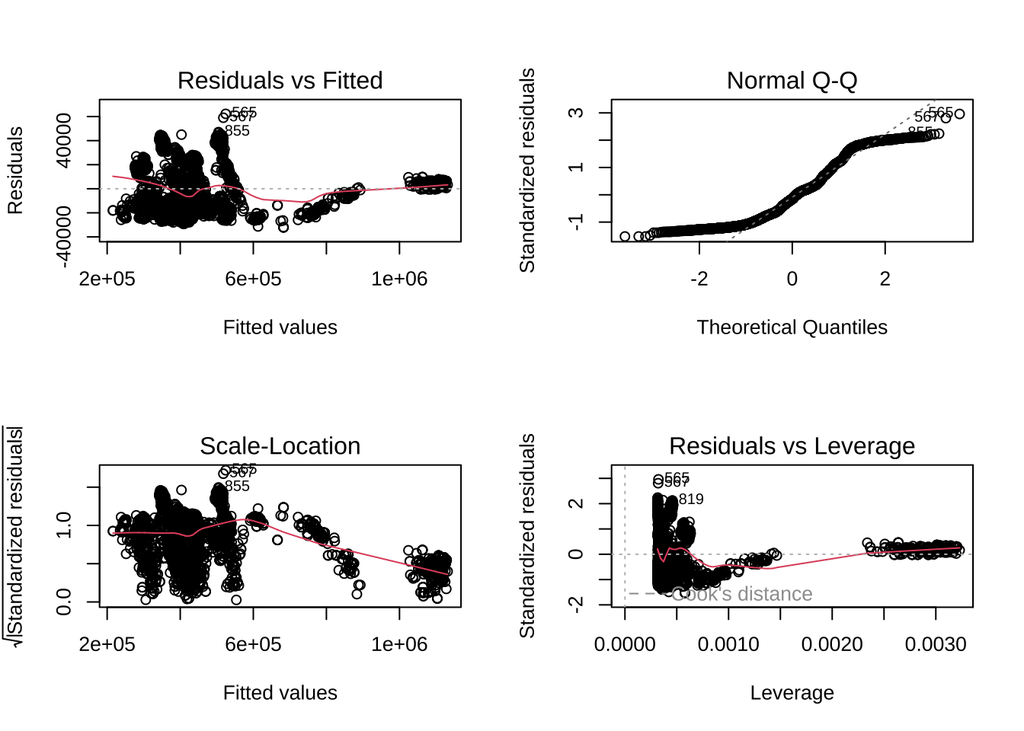

```r
par(mfrow = c(2,2))
plot(lm_max_population.fit)
```

Cluster가 되어있는 것으로 보아 각 구가 주간 인구수와 일 최대 인구수의 관계를 결정하는 듯 보인다.

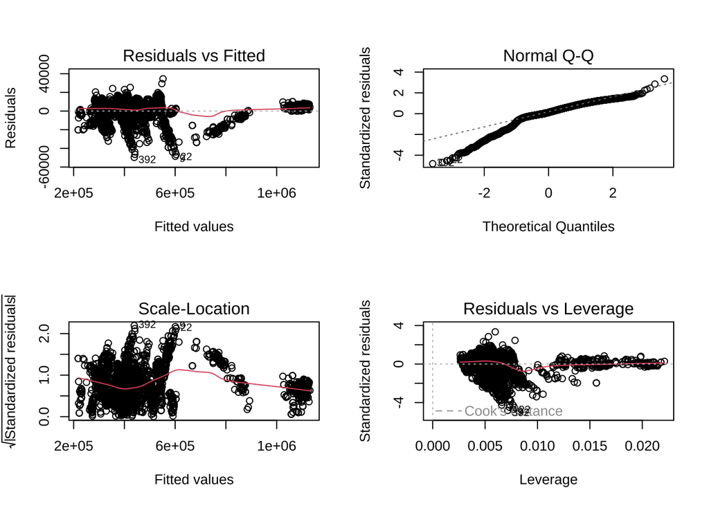

```r
lm_max_population.fit2 <- lm(일최대인구수 ~  주간인구수.09.18. + 주간인구수.09.18.:시군구, data = data)

par(mfrow = c(2,2))
plot(lm_max_population.fit2)
```

개선된 모습이다. 그러나 완전히 효과가 사라지진 않았다. 강수량을 추가 interaction으로 넣어봤다.

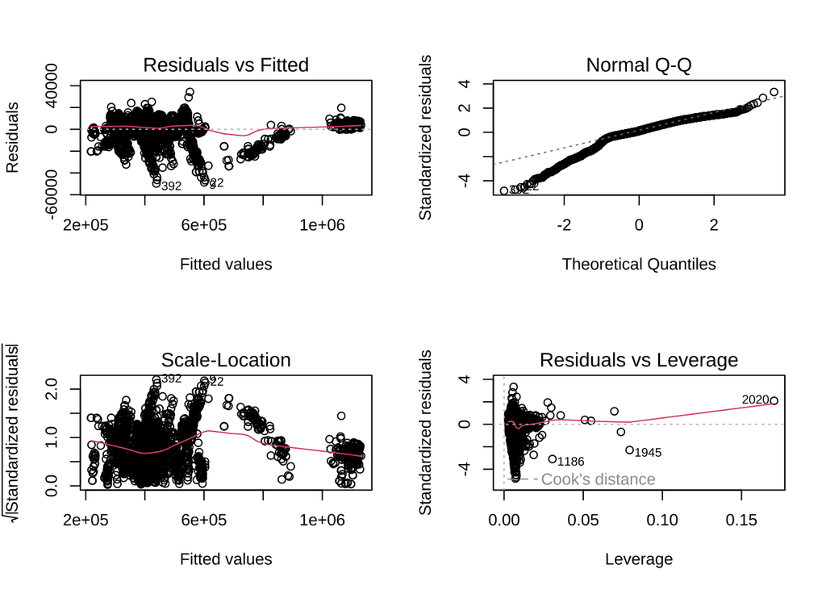

```r
lm_max_population.fit3 <- lm(일최대인구수 ~  주간인구수.09.18. + 주간인구수.09.18.:시군구 + 주간인구수.09.18.:강수량, data = data)

par(mfrow = c(2,2))
plot(lm_max_population.fit3)
```

강수량이 원인은 아닌 것으로 보인다.

## 가스 이용량과 전기 이용량의 관계

```r
data_energy <- data %>%
  select("가스이용량", "전기이용량", "시군구")
```

### Plot 가스 이용량 vs 전기 이용량

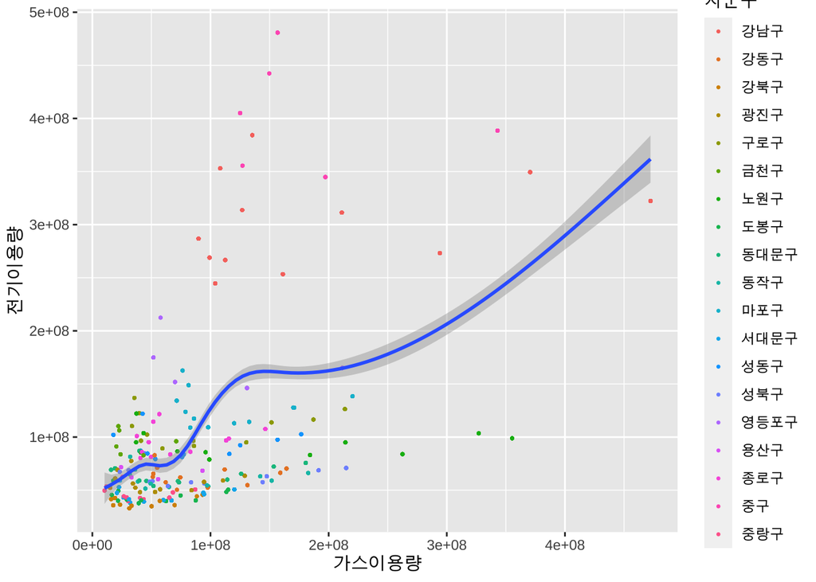

```r
data_energy %>%
  ggplot(aes(가스이용량, 전기이용량))+
  geom_point(aes(color = 시군구), size = 0.5)+
  geom_smooth()
```

그래프의 좌측 하단에 데이터가 많은 것을 확인하여 그 영역에 대해 그래프를 다시 그려보았다.

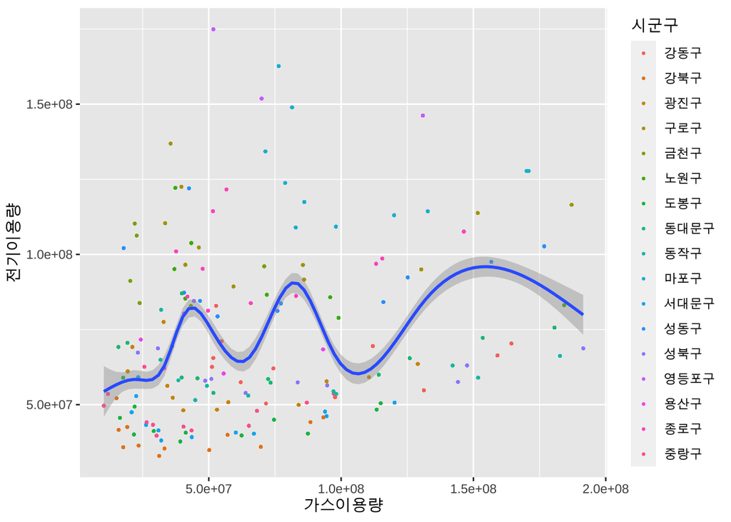

```r
data_energy %>%
  filter(가스이용량 < 2e+08, 전기이용량 < 2e+08)%>%
  ggplot(aes(가스이용량, 전기이용량))+
  geom_point(aes(color = 시군구), size = 0.5)+
  geom_smooth()
```

명확한 패턴을 찾을 수 없었다.

### 화재 발생 시에서만 데이터를 수집했기에, 실제로 데이터에서 구별로 특성이 없는지, 전기이용량과 가스이용량이 서로 관련이 없는지 확인할 필요성이 있다.

## 습도와 강수량의 관계 및 구의 영향 분석

```r
data_humidity <- data %>%
  select(강수량, 습도, 시군구)
```

### Plot 습도 vs 강수량

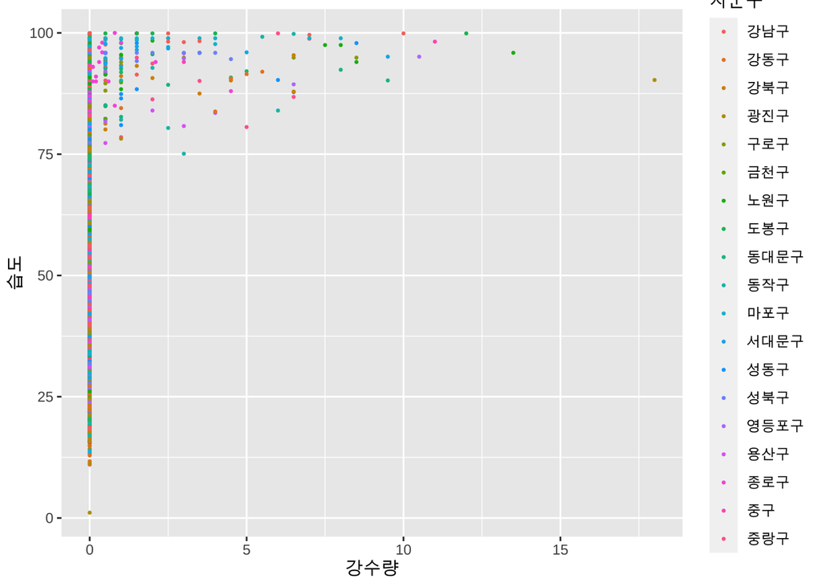

```r
data_humidity %>%
  ggplot(aes(강수량, 습도))+
  geom_point(aes(color = 시군구), size = 0.5)
```

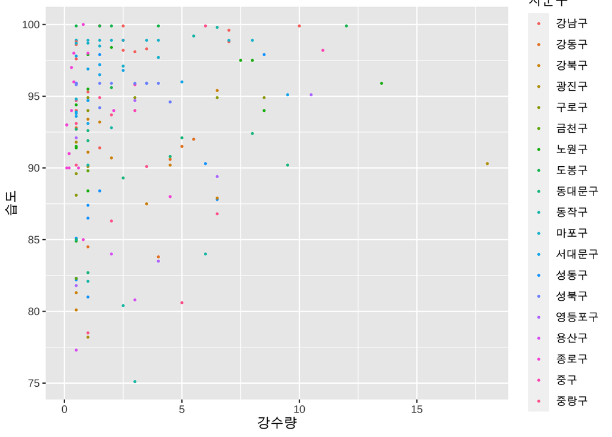

```r
data_humidity %>%
  filter(강수량 != 0) %>%
  ggplot(aes(강수량, 습도))+
  geom_point(aes(color = 시군구), size = 0.5)
```

비가 온 날은 습도가 높다는 것을 확인할 수 있다. 그리고 강수량이 주어질 때 습도의 하한이 있다는 것도 알아낼 수 있다.

# 재산피해량 분석

## 재산 피해량 Outlier 분석

### 재산 피해량 boxplot

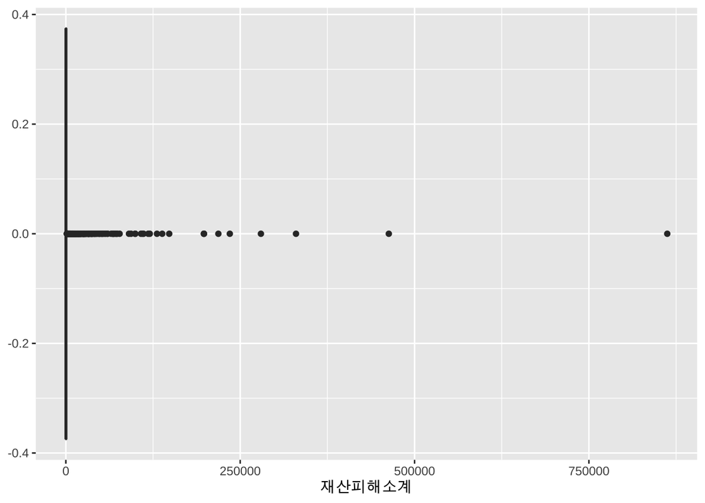

```r
data %>%
  ggplot()+
  geom_boxplot(aes(x = 재산피해소계))
```

### 재산피해의 Outlier 탐색

재산피해소계가 1.5*IQR 혹은 125000을 넘어가는 사건을 정리했다.

```r
IQR <- quantile(data$재산피해소계, 0.75) - quantile(data$재산피해소계, 0.25)

data %>%
  filter(data$재산피해소계 < median(data$재산피해소계) - 1.5*IQR | data$재산피해소계 > median(data$재산피해소계) + 1.5 * IQR) %>%
  dim()
```

```
## [1] 666  32
```

1.5 IQR 기준은 그로부터 떨어진 데이터가 너무 많았다. (3182개 obs 중에 666개였다)

```r
data %>%
  filter(data$재산피해소계 > 125000)
```

```
##      시군구            화재유형   발화열원대분류 발화요인대분류
## 1    강남구 기타(쓰레기 화재등) 담뱃불, 라이터불         부주의
## 2    구로구         건축,구조물             미상           미상
## 3    광진구     자동차,철도차량         작동기기    전기적 요인
## 4    성북구         건축,구조물             미상           미상
## 5    광진구     자동차,철도차량 마찰, 전도, 복사    기계적 요인
## 6    구로구         건축,구조물             미상           미상
## 7    구로구         건축,구조물         작동기기    전기적 요인
## 8    성동구         건축,구조물       불꽃, 불티         부주의
## 9      중구         건축,구조물       불꽃, 불티         부주의
## 10   구로구     자동차,철도차량         작동기기    기계적 요인
## 11   강북구         건축,구조물             미상           미상
## 12 동대문구         건축,구조물             미상           미상
##               최초착화물대분류 재산피해소계      장소대분류 기온  풍향 풍속
## 1             종이,목재,건초등       148219            기타 -6.0   0.0  0.3
```

[output cut: 76 more lines]

## 재산 피해량의 log변환 후 분석

### Log 변환 방법

```r
data %>%
  filter(재산피해소계 == 0) %>%
  dim()
```

```
## [1] 120  32
```

120 건의 화재에 대해서 재산 피해량이 0이었다.

```r
data %>%
  filter(재산피해소계 != 0)%>%
  arrange(재산피해소계)%>%
  head(5)
```

```
##   시군구            화재유형   발화열원대분류 발화요인대분류 최초착화물대분류
## 1 성북구 기타(쓰레기 화재등)       불꽃, 불티         부주의 종이,목재,건초등
## 2 노원구         건축,구조물         작동기기         부주의      침구,직물류
## 3 노원구         건축,구조물 담뱃불, 라이터불         부주의         쓰레기류
## 4 중랑구         건축,구조물 마찰, 전도, 복사         부주의             식품
## 5 광진구 기타(쓰레기 화재등)       불꽃, 불티         부주의         쓰레기류
##   재산피해소계 장소대분류 기온  풍향 풍속 강수량 습도 차량수 총생활인구수
## 1            1       기타 -7.5 339.3  0.8      0 46.5  29.10     453802.6
## 2            1       주거 -7.8 307.7  1.2      0 31.8  20.18     543646.4
## 3            1       주거 -8.8 250.1  1.5      0 36.8  18.25     543646.4
## 4            1       주거 -0.8 281.5  5.7      0 37.2  22.79     361792.9
## 5            1       기타 -7.8 287.9  3.1      0 36.2  28.82     378680.0
##   내국인생활인구수 장기체류외국인인구수 단기체류외국인인구수 일최대인구수
## 1         436249.6            14884.347            2668.6670     464390.8
## 2         537716.1             5059.499             870.7372     556389.4
```

[output cut: 21 more lines]

재산피해소계는 1이 최소 단위임을 확인할 수 있다. 뉴스를 종합한 결과 재산피해액이 1000원 단위로 쓰여졌음을 알 수 있었다. log 변환 시 양수가 들어가야하기 때문에 1000원은 예측하고자 하는 재산피해량에 큰 영향을 주지 않는다고 판단하여 1을 더하여 로그 변환을 진행하였다.

### 이 1을 더하는 행위가 합리적인지 검토해야함.

### boxplot

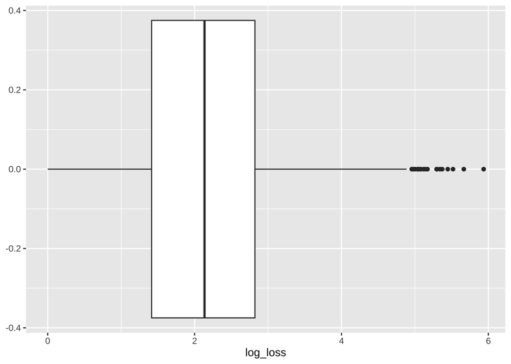

```r
data %>%
  mutate(log_loss = log(재산피해소계+1, base = 10)) %>%
  ggplot(aes(x = log_loss))+
  geom_boxplot()
```

### Log 재산피해의 Outlier

```r
IQR <- quantile(log(data$재산피해소계+1), 0.75) - quantile(log(data$재산피해소계+1), 0.25)
med <- quantile(log(data$재산피해소계+1), 0.5)

data %>%
  mutate(log_loss = log(재산피해소계+1, base = 10)) %>%
  filter(log_loss < med - 1.5 * IQR | log_loss > med + 1.5 * IQR) %>%
  dim()
```

```
## [1] 120  33
```

모두 재산피해액이 0이었던 지역이었다.

### Log 변환 histogram

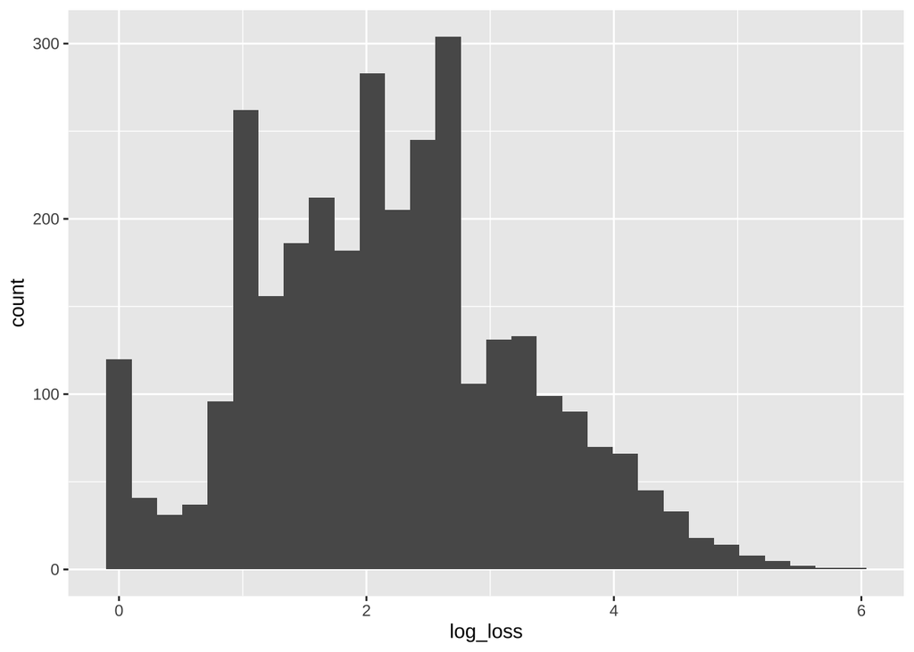

```r
data %>%
  mutate(log_loss = log(재산피해소계+1, base = 10)) %>%
  ggplot()+
  geom_histogram(aes(x = log_loss))
```

## BOX-COX transform

### 근거

Log 변환이 앞서 보았듯 0에서 문제를 일으키고, 변환 후에도 약간의 right skewed graph가 나왔기 때문에 BOX-COX transform을 고려해보게 되었다.

### BOX - COX 결과 (Full model 기준) & R square 기준

```r
Box_Cox_R2 <- c()

for(lambda1 in seq(0, 1, by = 0.1)){
  for(lambda2 in seq(-2, 2, by = 0.1)){
    if(lambda1 == 0){
      next
    }
    if(lambda2 == 0){
      data_lambda <- data %>%
        mutate(transform = log(재산피해소계 + lambda1))
    }else{
      data_lambda <- data %>%
        mutate(transform = ((재산피해소계 + lambda1)^lambda2 - 1 )/lambda2)
    }

    lm_full_lambda <- lm(transform ~ .-재산피해소계, data = data_lambda)

    Box_Cox_R2 <- c(Box_Cox_R2, c(lambda1, lambda2, summary(lm_full_lambda)$r.squared))
  }
}

as.data.frame(t(matrix(Box_Cox_R2, nrow = 3))) %>%
  rename("lambda1" = "V1", "lambda2" = "V2", "r.squared" = "V3") %>%
  arrange(desc(r.squared)) %>%
  head(5)
```

```
##   lambda1 lambda2 r.squared
## 1     0.4       0 0.3341942
## 2     0.5       0 0.3341907
## 3     0.6       0 0.3341447
## 4     0.3       0 0.3341151
## 5     0.7       0 0.3340750
```

이 결과로 Box-Cox를 해보면

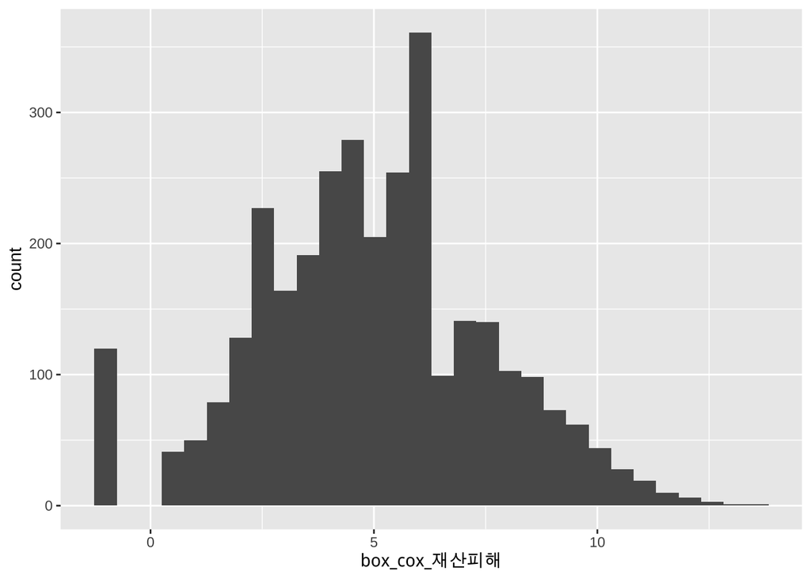

```r
data %>%
  mutate(box_cox_재산피해 = log(재산피해소계 + 0.4)) %>%
  ggplot()+
  geom_histogram(aes(x = box_cox_재산피해))
```

### BoxCox를 따를 지 log(+1) 이라는 기준을 따를 지 생각할 필요가 있다.

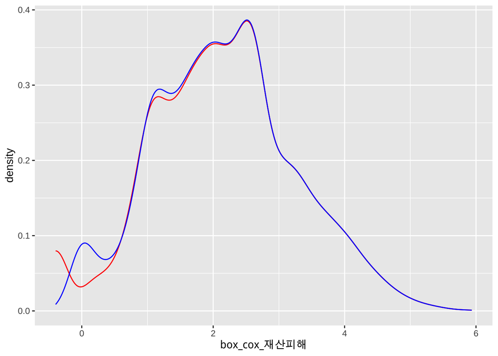

```r
data %>%
  mutate(box_cox_재산피해 = log(재산피해소계 + 0.4, base = 10)) %>%
  mutate(log1_재산피해 = log(재산피해소계 + 1, base = 10)) %>%
  ggplot()+
  geom_density(aes(x = box_cox_재산피해), color = "red")+
  geom_density(aes(x = log1_재산피해), color = "blue")
```

## 두 Dataset

```r
data_Box_Cox <- data %>%
  mutate(재산피해소계 = log(재산피해소계 + 0.4))
data_log1 <- data %>%
  mutate(재산피해소계 = log(재산피해소계 + 1))
```

# 재산피해량과 다른 변수의 관계 분석

## 화재 유형에 따른 재산피해량

```r
unique(data$화재유형)
```

```
## [1] "기타(쓰레기 화재등)" "건축,구조물"         "자동차,철도차량"
## [4] "임야"
```

### Boxplot

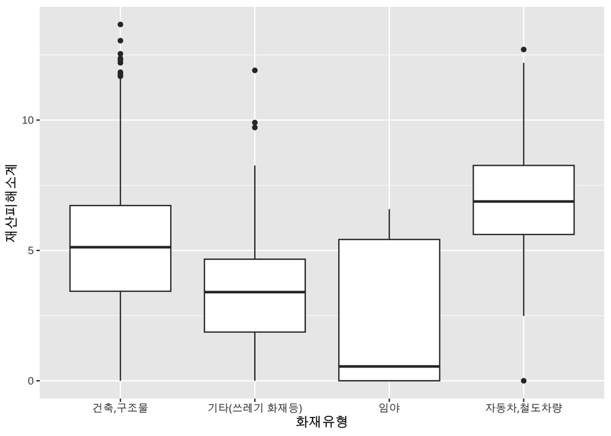

```r
data_log1 %>%
  select(화재유형, 재산피해소계) %>%
  ggplot(aes(화재유형, 재산피해소계))+
  geom_boxplot()
```

각 화재 건수는 다음과 같다.

```r
data_log1 %>%
  select(화재유형, 재산피해소계) %>%
  group_by(화재유형) %>%
  summarise(n = n(), mean = mean(재산피해소계))
```

```
## # A tibble: 4 × 3
##   화재유형                n  mean
##   <chr>               <int> <dbl>
## 1 건축,구조물          2471  5.21
## 2 기타(쓰레기 화재등)   471  3.25
## 3 임야                   14  2.44
## 4 자동차,철도차량       226  6.86
```

대다수가 건축, 구조물에서 발생한 화재이다.

### Lack of fit test

```r
model <- lm(재산피해소계 ~ 화재유형, data = data_log1)

null_model <- lm(재산피해소계 ~ 1, data = data_log1)

anova(model, null_model)
```

```
## Analysis of Variance Table
##
## Model 1: 재산피해소계 ~ 화재유형
## Model 2: 재산피해소계 ~ 1
##   Res.Df   RSS Df Sum of Sq      F    Pr(>F)
## 1   3178 17234
## 2   3181 19654 -3   -2420.2 148.76 < 2.2e-16 ***
## ---
## Signif. codes:  0 '***' 0.001 '**' 0.01 '*' 0.05 '.' 0.1 ' ' 1
```

전체 모델에 대해서는 모르지만, 이 카테고리 변수에 대해서는 회귀 분석을 하는 것이 옳다.

## 화재 발생 시간과 재산피해량

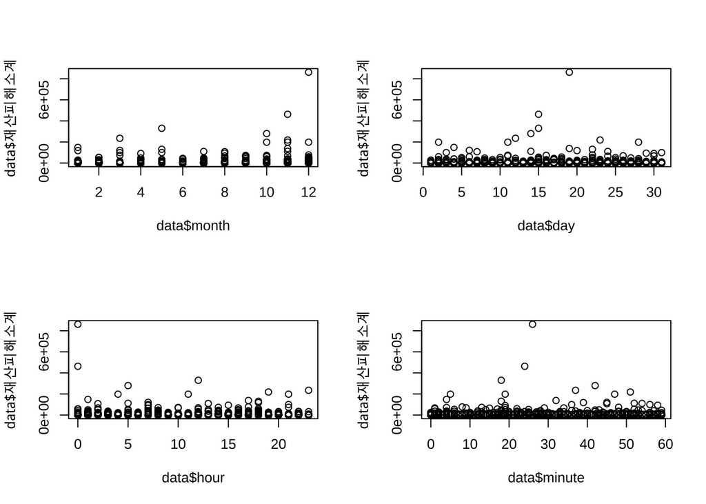

```r
par(mfrow = c(2,2))

plot(data$month, data$재산피해소계)
plot(data$day, data$재산피해소계)
plot(data$hour, data$재산피해소계)
plot(data$minute, data$재산피해소계)
```

### Lack of fit test

```r
model <- lm(재산피해소계 ~ month, data = data_log1)

null_model <- lm(재산피해소계 ~ 1, data = data_log1)

anova(model, null_model)
```

```
## Analysis of Variance Table
##
## Model 1: 재산피해소계 ~ month
## Model 2: 재산피해소계 ~ 1
##   Res.Df   RSS Df Sum of Sq      F Pr(>F)
## 1   3180 19648
## 2   3181 19654 -1   -5.6477 0.9141 0.3391
```

월 기준으로는 그리 유효하지 않았다.

```r
model <- lm(재산피해소계 ~ day, data = data_log1)

null_model <- lm(재산피해소계 ~ 1, data = data_log1)

anova(model, null_model)
```

```
## Analysis of Variance Table
##
## Model 1: 재산피해소계 ~ day
## Model 2: 재산피해소계 ~ 1
##   Res.Df   RSS Df Sum of Sq      F  Pr(>F)
## 1   3180 19628
## 2   3181 19654 -1   -26.385 4.2747 0.03876 *
## ---
## Signif. codes:  0 '***' 0.001 '**' 0.01 '*' 0.05 '.' 0.1 ' ' 1
```

일 기준으로는 유효하게 나타났으며

```r
model <- lm(재산피해소계 ~ hour, data = data_log1)

null_model <- lm(재산피해소계 ~ 1, data = data_log1)

anova(model, null_model)
```

```
## Analysis of Variance Table
##
## Model 1: 재산피해소계 ~ hour
## Model 2: 재산피해소계 ~ 1
##   Res.Df   RSS Df Sum of Sq      F    Pr(>F)
## 1   3180 19301
## 2   3181 19654 -1   -353.16 58.185 3.131e-14 ***
## ---
## Signif. codes:  0 '***' 0.001 '**' 0.01 '*' 0.05 '.' 0.1 ' ' 1
```

시간은 유효하게 영향을 주었다.

```r
model <- lm(재산피해소계 ~ minute, data = data_log1)

null_model <- lm(재산피해소계 ~ 1, data = data_log1)

anova(model, null_model)
```

```
## Analysis of Variance Table
##
## Model 1: 재산피해소계 ~ minute
## Model 2: 재산피해소계 ~ 1
##   Res.Df   RSS Df Sum of Sq      F  Pr(>F)
## 1   3180 19633
## 2   3181 19654 -1    -21.28 3.4467 0.06347 .
## ---
## Signif. codes:  0 '***' 0.001 '**' 0.01 '*' 0.05 '.' 0.1 ' ' 1
```

분은 큰 영향을 주진 않다. 0.05를 유의수준으로 설정하면 유효하지 않다고 볼 수 있다.

## 화재 발생 시간의 interaction term 고려 여부 : hour

### Hour & Minute

```r
model <- lm(재산피해소계 ~ hour*minute , data = data_log1)

null_model <- lm(재산피해소계 ~ hour + minute, data = data_log1)

anova(model, null_model)
```

```
## Analysis of Variance Table
##
## Model 1: 재산피해소계 ~ hour * minute
## Model 2: 재산피해소계 ~ hour + minute
##   Res.Df   RSS Df Sum of Sq      F  Pr(>F)
## 1   3178 19254
## 2   3179 19278 -1   -23.756 3.9209 0.04777 *
## ---
## Signif. codes:  0 '***' 0.001 '**' 0.01 '*' 0.05 '.' 0.1 ' ' 1
```

### Hour & day

```r
model <- lm(재산피해소계 ~ hour*day , data = data_log1)

null_model <- lm(재산피해소계 ~ hour + day, data = data_log1)

anova(model, null_model)
```

```
## Analysis of Variance Table
##
## Model 1: 재산피해소계 ~ hour * day
## Model 2: 재산피해소계 ~ hour + day
##   Res.Df   RSS Df Sum of Sq     F Pr(>F)
## 1   3178 19270
## 2   3179 19271 -1  -0.83042 0.137 0.7114
```

### 화재 발생 시각 : hour * minute + day

```r
time_model <- lm(재산피해소계 ~ hour*minute + day, data = data_log1)

summary(time_model)
```

```
##
## Call:
## lm(formula = 재산피해소계 ~ hour * minute + day, data = data_log1)
##
## Residuals:
##     Min      1Q  Median      3Q     Max
## -6.0763 -1.7863 -0.0842  1.4996  7.9305
##
## Coefficients:
##               Estimate Std. Error t value Pr(>|t|)
## (Intercept)  6.3535873  0.2171182  29.263  < 2e-16 ***
## hour        -0.0747006  0.0135120  -5.528 3.49e-08 ***
## minute      -0.0154805  0.0058871  -2.630  0.00859 **
## day         -0.0112734  0.0049871  -2.261  0.02386 *
## hour:minute  0.0007815  0.0003972   1.967  0.04923 *
## ---
## Signif. codes:  0 '***' 0.001 '**' 0.01 '*' 0.05 '.' 0.1 ' ' 1
##
## Residual standard error: 2.46 on 3177 degrees of freedom
## Multiple R-squared:  0.02191,    Adjusted R-squared:  0.02068
## F-statistic: 17.79 on 4 and 3177 DF,  p-value: 1.86e-14
```

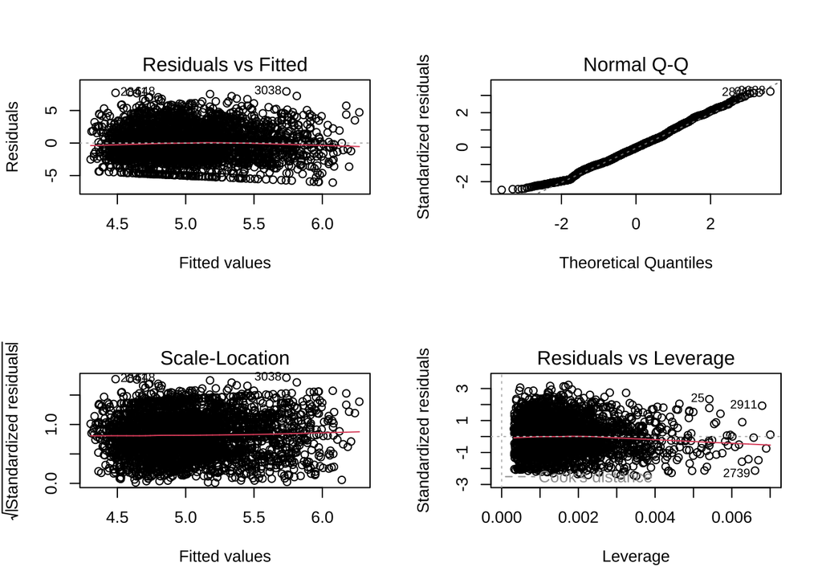

```r
par(mfrow = c(2,2))
plot(time_model)
```

### 화재 발생 시각 : hour + day

```r
time_model <- lm(재산피해소계 ~ hour + day, data = data_log1)

summary(time_model)
```

```
##
## Call:
## lm(formula = 재산피해소계 ~ hour + day, data = data_log1)
##
## Residuals:
##    Min     1Q Median     3Q    Max
## -5.871 -1.766 -0.082  1.510  7.987
##
## Coefficients:
##              Estimate Std. Error t value Pr(>|t|)
## (Intercept)  5.893026   0.129224  45.603  < 2e-16 ***
## hour        -0.051499   0.006709  -7.676 2.17e-14 ***
## day         -0.011180   0.004991  -2.240   0.0252 *
## ---
## Signif. codes:  0 '***' 0.001 '**' 0.01 '*' 0.05 '.' 0.1 ' ' 1
##
## Residual standard error: 2.462 on 3179 degrees of freedom
## Multiple R-squared:  0.01952,    Adjusted R-squared:  0.0189
## F-statistic: 31.64 on 2 and 3179 DF,  p-value: 2.481e-14
```

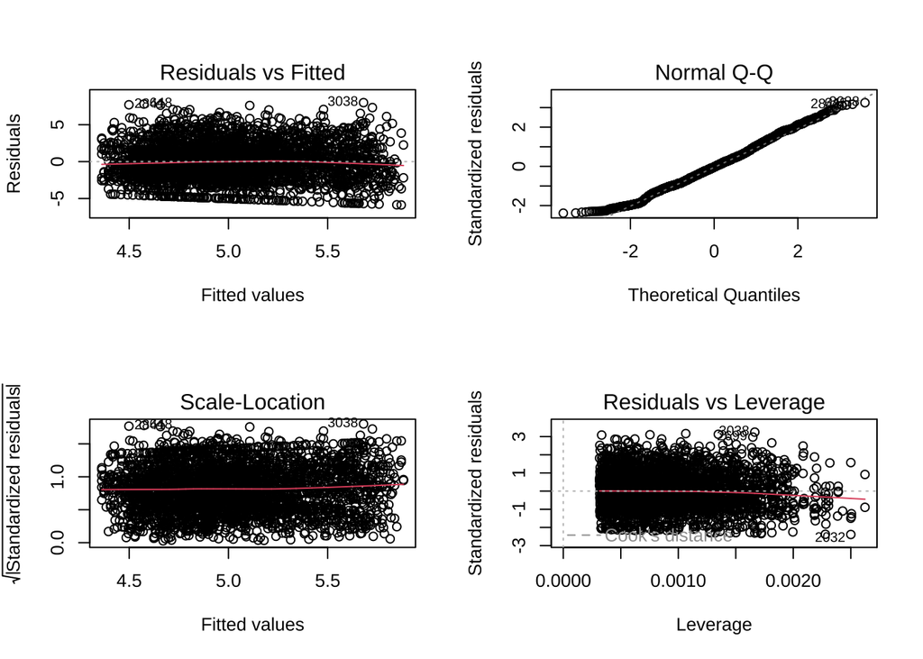

```r
par(mfrow = c(2,2))
plot(time_model)
```

## 구에 따른 재산피해 차이

### 구 정보

```r
unique(data_log1$시군구)
```

```
##  [1] "강남구"   "중랑구"   "동대문구" "성북구"   "구로구"   "노원구"
##  [7] "동작구"   "마포구"   "도봉구"   "강북구"   "서대문구" "강동구"
## [13] "성동구"   "종로구"   "광진구"   "중구"     "금천구"   "영등포구"
## [19] "용산구"
```

### Boxplot

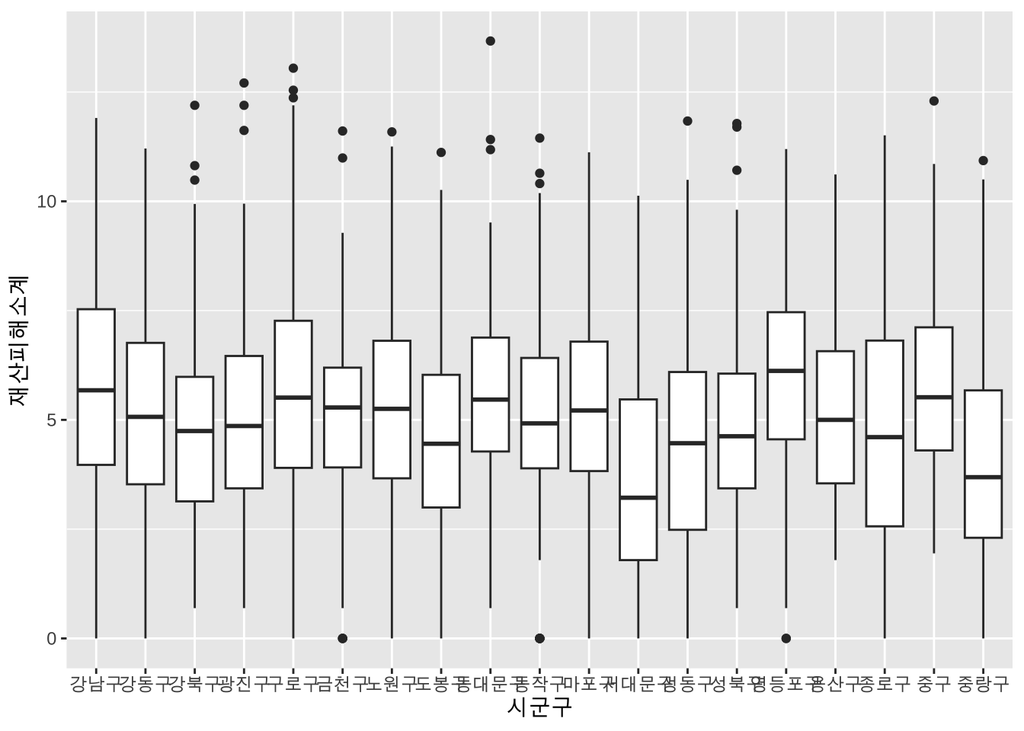

```r
data_log1 %>%
  ggplot()+
  geom_boxplot(aes(x = 시군구, y = 재산피해소계))
```

### Lack of fit test

구마다 유의미한 차이가 나타나는지 본다.

```r
model <- lm(재산피해소계 ~ 시군구 , data = data_log1)

null_model <- lm(재산피해소계 ~ 1, data = data_log1)

anova(model, null_model)
```

```
## Analysis of Variance Table
##
## Model 1: 재산피해소계 ~ 시군구
## Model 2: 재산피해소계 ~ 1
##   Res.Df   RSS  Df Sum of Sq      F    Pr(>F)
## 1   3163 18471
## 2   3181 19654 -18   -1182.8 11.252 < 2.2e-16 ***
## ---
## Signif. codes:  0 '***' 0.001 '**' 0.01 '*' 0.05 '.' 0.1 ' ' 1
```